# Unsupervised_Learning_R4_Project1_Car_mpg

The dataset was used in the 1983 American Statistical Association Exposition. The data concerns city-cycle fuel consumption in miles per gallon, to be predicted in terms of 2 multivalued discrete and 4 continuous variables.

Dataset: cars-dataset.csvView in a new window

Attribute Information:

Car Name – Name of the car

Cyl – No of cylinders in the car – Multivalued discrete

Disp – Displacement – continuous

Hp – Horsepower – continuous

Wt – Weight – continuous

Acc – Accleration – continuous

Yr – Model of the car – Multivalued discrete

Steps to follow:

EDA & Pre-processing (Make sure to remove all non-numeric entries from numeric columns) – 2.5 points  
Use pair plot or scatter matrix to visualize how the different variables are related (Hint: The amount of Gaussian curves in the plot should give a visual identification of different clusters existing in the dataset) – 5 points  
Use K Means or Hierarchical clustering to find out the optimal no of clusters in the data. Identify and separate the clusters (15 points)  
Use linear regression model on different clusters separately and print the coefficients of the models individually (7.5 points)

```python
# Numerical libraries
import numpy as np

# Import Linear Regression machine learning library
from sklearn.linear_model import LinearRegression

# to handle data in form of rows and columns
import pandas as pd

# importing ploting libraries
import matplotlib.pyplot as plt

#importing seaborn for statistical plots
import seaborn as sns
from scipy.stats import zscore
from sklearn.model_selection import train_test_split
from sklearn.cluster import KMeans
from scipy.spatial import distance
from scipy.cluster.hierarchy import cophenet, dendrogram, linkage
from scipy.spatial.distance import pdist  #Pairwise distribution between data points
from scipy.cluster.hierarchy import fcluster
from sklearn import metrics
from sklearn.linear_model import LinearRegression
```

```python
car_mpg_df = pd.read_csv('cars-dataset.csv')
```

```python
car_mpg_df.sample(5)
```

|  | car name | cyl | disp | hp | wt | acc | yr | mpg |
| --- | --- | --- | --- | --- | --- | --- | --- | --- |
| 159 | ford ltd | 8 | 351.0 | 148 | 4657 | 13.5 | 75 | 14.0 |
| 388 | chrysler lebaron medallion | 4 | 156.0 | 92 | 2585 | 14.5 | 82 | 26.0 |
| 237 | chevrolet chevette | 4 | 98.0 | 63 | 2051 | 17.0 | 77 | 30.5 |
| 224 | mercury cougar brougham | 8 | 302.0 | 130 | 4295 | 14.9 | 77 | 15.0 |
| 381 | honda accord | 4 | 107.0 | 75 | 2205 | 14.5 | 82 | 36.0 |

```python
car_mpg_df.shape
```

```
(398, 8)
```

```python
car_mpg_df.columns
```

```
Index(['car name', 'cyl', 'disp', 'hp', 'wt', 'acc', 'yr', 'mpg'], dtype='object')
```

```python
car_mpg_df.info()
```

```
<class 'pandas.core.frame.DataFrame'>
RangeIndex: 398 entries, 0 to 397
Data columns (total 8 columns):
car name    398 non-null object
cyl         398 non-null int64
disp        398 non-null float64
hp          398 non-null object
wt          398 non-null int64
acc         398 non-null float64
yr          398 non-null int64
mpg         398 non-null float64
dtypes: float64(3), int64(3), object(2)
memory usage: 25.0+ KB
```

```python
car_mpg_df.describe().T
```

|  | count | mean | std | min | 25% | 50% | 75% | max |
| --- | --- | --- | --- | --- | --- | --- | --- | --- |
| cyl | 398.0 | 5.454774 | 1.701004 | 3.0 | 4.000 | 4.0 | 8.000 | 8.0 |
| disp | 398.0 | 193.425879 | 104.269838 | 68.0 | 104.250 | 148.5 | 262.000 | 455.0 |
| wt | 398.0 | 2970.424623 | 846.841774 | 1613.0 | 2223.750 | 2803.5 | 3608.000 | 5140.0 |
| acc | 398.0 | 15.568090 | 2.757689 | 8.0 | 13.825 | 15.5 | 17.175 | 24.8 |
| yr | 398.0 | 76.010050 | 3.697627 | 70.0 | 73.000 | 76.0 | 79.000 | 82.0 |
| mpg | 398.0 | 23.514573 | 7.815984 | 9.0 | 17.500 | 23.0 | 29.000 | 46.6 |

## Observation that can be derived

### Car name and horse power are object type

### Since horse power cannot be of object type we have to further analyse this.

```python
temp = pd.DataFrame(car_mpg_df.hp.str.isdigit())
car_mpg_df[ temp['hp'] == False ]
```

|  | car name | cyl | disp | hp | wt | acc | yr | mpg |
| --- | --- | --- | --- | --- | --- | --- | --- | --- |
| 32 | ford pinto | 4 | 98.0 | ? | 2046 | 19.0 | 71 | 25.0 |
| 126 | ford maverick | 6 | 200.0 | ? | 2875 | 17.0 | 74 | 21.0 |
| 330 | renault lecar deluxe | 4 | 85.0 | ? | 1835 | 17.3 | 80 | 40.9 |
| 336 | ford mustang cobra | 4 | 140.0 | ? | 2905 | 14.3 | 80 | 23.6 |
| 354 | renault 18i | 4 | 100.0 | ? | 2320 | 15.8 | 81 | 34.5 |
| 374 | amc concord dl | 4 | 151.0 | ? | 3035 | 20.5 | 82 | 23.0 |

### We can see that Horse power contains '?' which indicates missing values

### # There are various ways to handle missing values. Drop the rows, replace missing values with median values or as per business requirements

```python
car_mpg_df = car_mpg_df.replace('?',np.nan)
```

```python
car_mpg_df.info()
```

```
<class 'pandas.core.frame.DataFrame'>
RangeIndex: 398 entries, 0 to 397
Data columns (total 8 columns):
car name    398 non-null object
cyl         398 non-null int64
disp        398 non-null float64
hp          392 non-null object
wt          398 non-null int64
acc         398 non-null float64
yr          398 non-null int64
mpg         398 non-null float64
dtypes: float64(3), int64(3), object(2)
memory usage: 25.0+ KB
```

```python
from sklearn.impute import SimpleImputer
imputer = SimpleImputer(strategy="median")
```

```python
car_mpg_df = car_mpg_df.drop('car name',axis=1)
```

```python
car_mpg_df.head(2)
```

|  | cyl | disp | hp | wt | acc | yr | mpg |
| --- | --- | --- | --- | --- | --- | --- | --- |
| 0 | 8 | 307.0 | 130 | 3504 | 12.0 | 70 | 18.0 |
| 1 | 8 | 350.0 | 165 | 3693 | 11.5 | 70 | 15.0 |

```python
imputer.fit(car_mpg_df)
```

```
SimpleImputer(copy=True, fill_value=None, missing_values=nan,
       strategy='median', verbose=0)
```

```python
imputer.statistics_
```

```
array([   4. ,  148.5,   93.5, 2803.5,   15.5,   76. ,   23. ])
```

```python
car_mpg_df.median().values
```

```
array([   4. ,  148.5,   93.5, 2803.5,   15.5,   76. ,   23. ])
```

```python
X = imputer.transform(car_mpg_df)
car_mpg_df = pd.DataFrame(X, columns=car_mpg_df.columns,
                          index=car_mpg_df.index)
```

```python
car_mpg_df.describe().T
```

|  | count | mean | std | min | 25% | 50% | 75% | max |
| --- | --- | --- | --- | --- | --- | --- | --- | --- |
| cyl | 398.0 | 5.454774 | 1.701004 | 3.0 | 4.000 | 4.0 | 8.000 | 8.0 |
| disp | 398.0 | 193.425879 | 104.269838 | 68.0 | 104.250 | 148.5 | 262.000 | 455.0 |
| hp | 398.0 | 104.304020 | 38.222625 | 46.0 | 76.000 | 93.5 | 125.000 | 230.0 |
| wt | 398.0 | 2970.424623 | 846.841774 | 1613.0 | 2223.750 | 2803.5 | 3608.000 | 5140.0 |
| acc | 398.0 | 15.568090 | 2.757689 | 8.0 | 13.825 | 15.5 | 17.175 | 24.8 |
| yr | 398.0 | 76.010050 | 3.697627 | 70.0 | 73.000 | 76.0 | 79.000 | 82.0 |
| mpg | 398.0 | 23.514573 | 7.815984 | 9.0 | 17.500 | 23.0 | 29.000 | 46.6 |

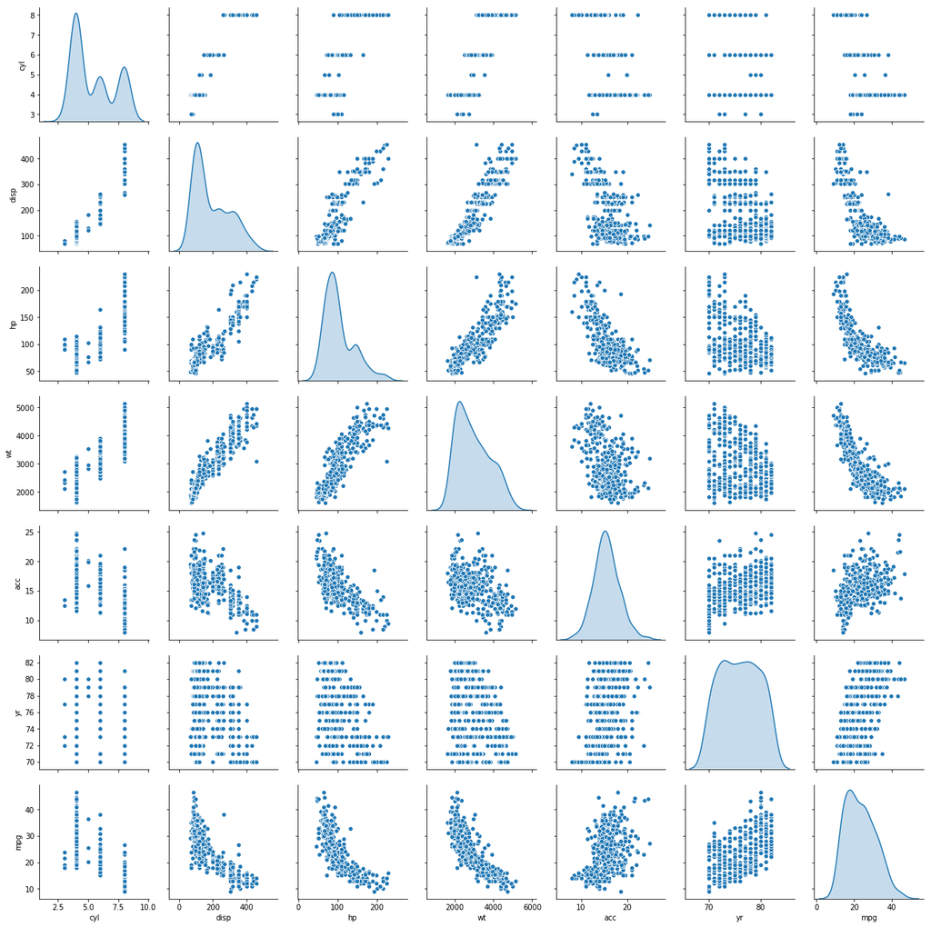

```python
sns.pairplot(car_mpg_df, diag_kind='kde')
```

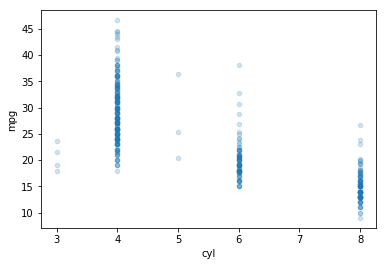

```python
car_mpg_df.plot(kind="scatter", x="cyl", y="mpg", alpha=0.2)
```

### From pair plot we can see that we have atleast 3 clusters

### From scatter plot we can also see that car can be segmented into 3 types based on cylenders

### Small cars have 4 cylenders , Mid size cars have 6 cylenders and big or heavy cars have 8 cylenders

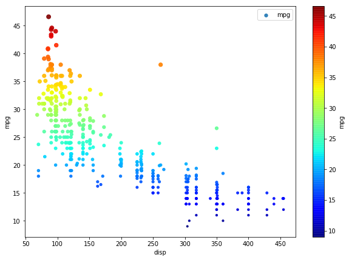

```python
car_mpg_df.plot(kind="scatter", x="disp", y="mpg", alpha=0.9,
    s=car_mpg_df["mpg"], label="mpg", figsize=(10,7),
    c="mpg", cmap=plt.get_cmap("jet"), colorbar=True,
    sharex=False)
plt.legend()
```

### From Above scatter plot it can be concluded that there are 3-4 clusters , One for heavy cars , one for mid size cars , one for small and one for very small cars

## Since different dimensions have different scales it would be wise to standardize the data using z scores before we go for any clustering methods.

```python
car_mpg_df_z = car_mpg_df.apply(zscore)
```

## K - Means Clustering

```python
cluster_range = range(2,7)
cluster_errors = []
distortion = []
cluster_sil_scores = []
for cluster_n in cluster_range :
    clusters = KMeans(cluster_n, n_init = 5)
    clusters.fit(car_mpg_df_z)
    labels = clusters.labels_
    cluster_errors.append(clusters.inertia_)
    distortion.append(sum(np.min(distance.cdist(car_mpg_df_z, clusters.cluster_centers_, 'euclidean'), axis=1))/ car_mpg_df_z.shape[0])
    cluster_sil_scores.append(metrics.silhouette_score(car_mpg_df_z, labels, metric='euclidean'))
clusters_df = pd.DataFrame( { "num_clusters":cluster_range, "cluster_errors": cluster_errors, "Avg Sil Score": cluster_sil_scores, "distortion": distortion } )
clusters_df[0:15]
```

|  | num_clusters | cluster_errors | Avg Sil Score | distortion |
| --- | --- | --- | --- | --- |
| 0 | 2 | 1294.841895 | 0.482359 | 1.696212 |
| 1 | 3 | 946.019791 | 0.353148 | 1.433775 |
| 2 | 4 | 738.415974 | 0.348543 | 1.253352 |
| 3 | 5 | 667.362520 | 0.310301 | 1.194851 |
| 4 | 6 | 594.715425 | 0.275495 | 1.128219 |

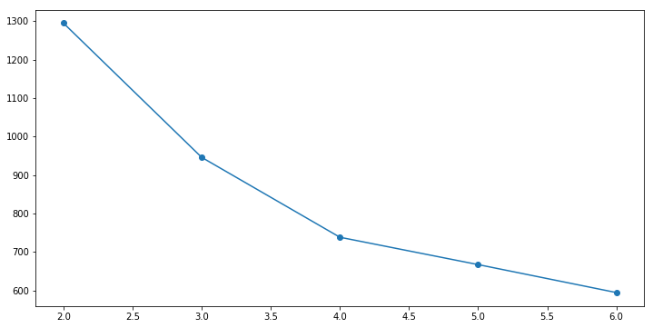

```python
# Elbow plot
plt.figure(figsize=(12,6))
plt.plot(clusters_df.num_clusters, clusters_df.cluster_errors, marker = "o")
```

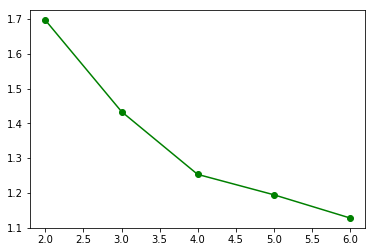

```python
plt.plot(range(2,7), distortion, 'go-')
```

### Optimal value of k is 4 As per analysing pair plot and elbow plot (bend is maximum at 4)

### Using optimal value of K - Cluster the data.

Note: Since the data has more than 2 dimension we cannot visualize the data. As an alternative, we can observe the centroids and note how they are distributed across different dimensions

```python
cluster = KMeans(n_clusters = 4, random_state = 100 )
cluster.fit(car_mpg_df_z)
car_mpg_df_z_copy = car_mpg_df_z.copy(deep= True)   # Creating a mirror copy for later re-use instead of building repeatedly
```

```python
centroids = cluster.cluster_centers_
centroids
```

```
array([[ 1.49819126,  1.50392292,  1.52168282,  1.40409797, -1.0861486 ,
        -0.68832385, -1.16379715],
       [-0.82534015, -0.78164519, -0.74051725, -0.76856959,  0.37498307,
         1.10179281,  1.18017325],
       [ 0.42443037,  0.30530323, -0.03775766,  0.33776539,  0.29367006,
         0.03298635, -0.49682681],
       [-0.86226631, -0.8085232 , -0.55740678, -0.75863563,  0.32955478,
        -0.64549188,  0.20271132]])
```

```python
centroid_df = pd.DataFrame(centroids , columns = list(car_mpg_df_z))
centroid_df
```

|  | cyl | disp | hp | wt | acc | yr | mpg |
| --- | --- | --- | --- | --- | --- | --- | --- |
| 0 | 1.498191 | 1.503923 | 1.521683 | 1.404098 | -1.086149 | -0.688324 | -1.163797 |
| 1 | -0.825340 | -0.781645 | -0.740517 | -0.768570 | 0.374983 | 1.101793 | 1.180173 |
| 2 | 0.424430 | 0.305303 | -0.037758 | 0.337765 | 0.293670 | 0.032986 | -0.496827 |
| 3 | -0.862266 | -0.808523 | -0.557407 | -0.758636 | 0.329555 | -0.645492 | 0.202711 |

```python
prediction=cluster.predict(car_mpg_df_z)
car_mpg_df_z["PREDICTED_CAR_TYPE"] = prediction
```

```python
car_mpg_df_z.sample(6)
```

|  | cyl | disp | hp | wt | acc | yr | mpg | PREDICTED_CAR_TYPE |
| --- | --- | --- | --- | --- | --- | --- | --- | --- |
| 346 | -0.856321 | -0.925936 | -0.977195 | -1.070524 | 0.810359 | 1.351199 | 1.125448 | 1 |
| 241 | 0.320935 | -0.455410 | -0.191332 | -0.183765 | -0.387801 | 0.268063 | -0.194023 | 2 |
| 139 | 1.498191 | 1.042591 | 0.935072 | 1.971648 | 0.156817 | -0.544290 | -1.218855 | 0 |
| 267 | -0.856321 | -0.570641 | -0.243723 | -0.485263 | -0.496725 | 0.538847 | 0.510549 | 1 |
| 158 | 1.498191 | 1.196232 | 1.197027 | 1.806120 | -0.387801 | -0.273506 | -0.962647 | 0 |
| 254 | 0.320935 | 0.063128 | -0.505677 | -0.006414 | 0.084201 | 0.538847 | -0.424610 | 2 |

```
array([[<matplotlib.axes._subplots.AxesSubplot object at 0x000001D45E943DA0>,
      dtype=object)
```

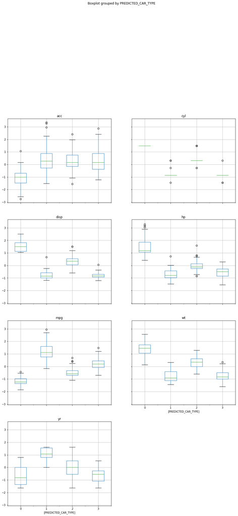

```python
car_mpg_df_z.boxplot(by = 'PREDICTED_CAR_TYPE',  layout=(11,2), figsize=(15, 77))
```

```
For n_clusters = 2 The average silhouette_score is : 0.48235946103916116
```

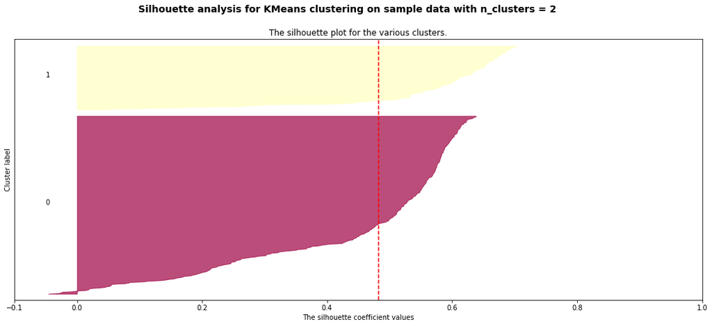

```
For n_clusters = 3 The average silhouette_score is : 0.35314791198988205
```

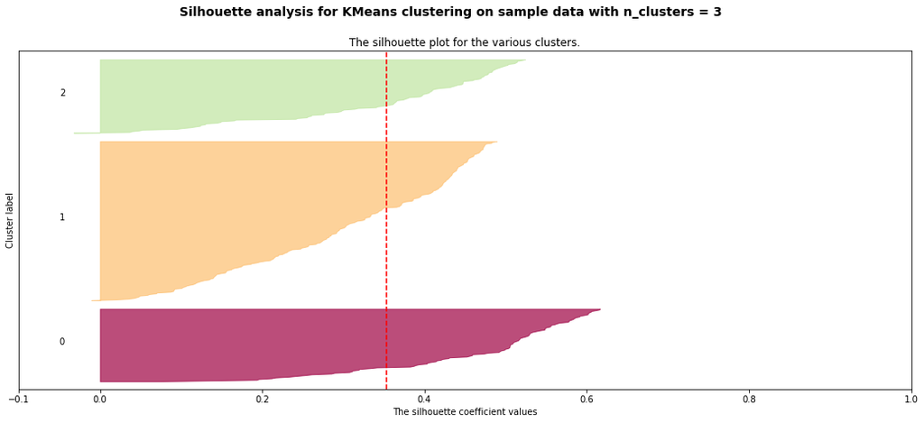

```
For n_clusters = 4 The average silhouette_score is : 0.34844881731503
```

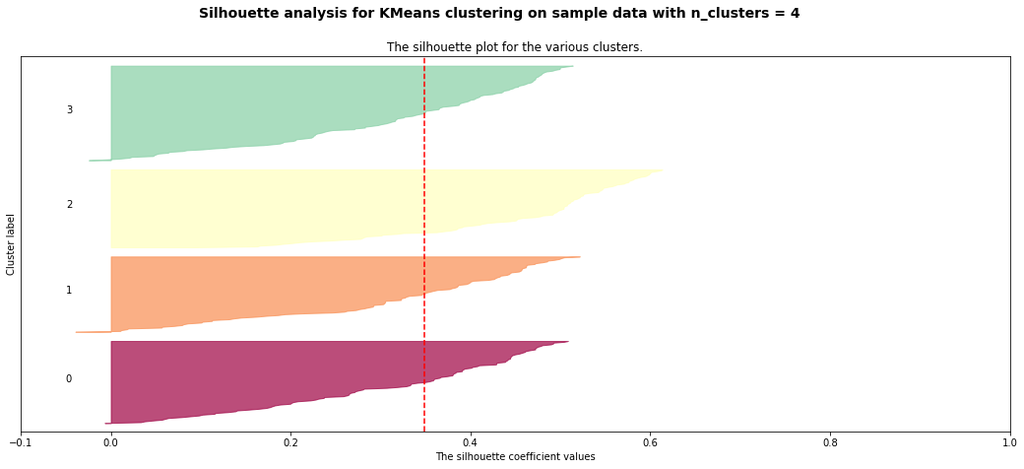

```
For n_clusters = 5 The average silhouette_score is : 0.31497575273047274
```

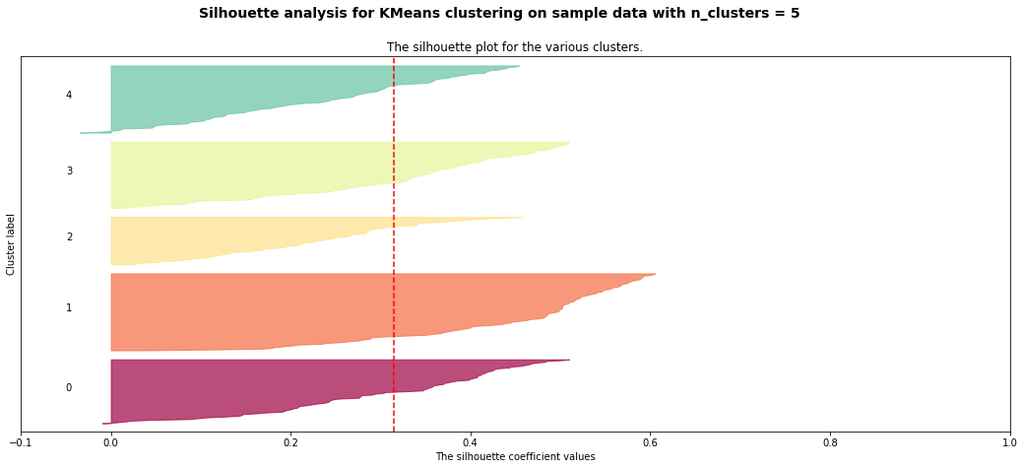

```
For n_clusters = 6 The average silhouette_score is : 0.2741945945851742
```

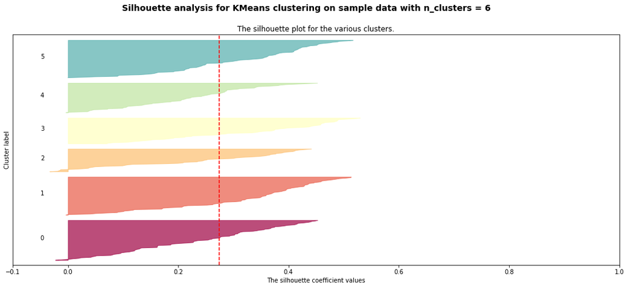

```python
%matplotlib inline
#from __future__ import print_function

#from sklearn.datasets import make_blobs
from sklearn.cluster import KMeans
from sklearn.metrics import silhouette_samples, silhouette_score

import matplotlib.pyplot as plt
import matplotlib.cm as cm
import numpy as np

#print(__doc__)

X = car_mpg_df_z.drop("PREDICTED_CAR_TYPE",axis=1)
y = car_mpg_df_z['PREDICTED_CAR_TYPE']
range_n_clusters = [2, 3, 4, 5, 6]

for n_clusters in range_n_clusters:
    # Create a subplot with 1 row and 2 columns
    fig, (ax1) = plt.subplots(1, 1)
    fig.set_size_inches(18, 7)

    # The 1st subplot is the silhouette plot
    # The silhouette coefficient can range from -1, 1
    ax1.set_xlim([-0.1, 1])
    # The (n_clusters+1)*10 is for inserting blank space between silhouette
    # plots of individual clusters, to demarcate them clearly.
    ax1.set_ylim([0, len(X) + (n_clusters + 1) * 10])

    # Initialize the clusterer with n_clusters value and a random generator
    # seed of 10 for reproducibility.
    clusterer = KMeans(n_clusters=n_clusters, random_state=10)
    cluster_labels = clusterer.fit_predict(X)

    # The silhouette_score gives the average value for all the samples.
    # This gives a perspective into the density and separation of the formed
    # clusters
    silhouette_avg = silhouette_score(X, cluster_labels)
    print("For n_clusters =", n_clusters,
          "The average silhouette_score is :", silhouette_avg)

    # Compute the silhouette scores for each sample
    sample_silhouette_values = silhouette_samples(X, cluster_labels)

    y_lower = 10
    for i in range(n_clusters):
        # Aggregate the silhouette scores for samples belonging to
        # cluster i, and sort them
        ith_cluster_silhouette_values = \
            sample_silhouette_values[cluster_labels == i]

        ith_cluster_silhouette_values.sort()

        size_cluster_i = ith_cluster_silhouette_values.shape[0]
        y_upper = y_lower + size_cluster_i

        color = cm.Spectral(float(i) / n_clusters)
        ax1.fill_betweenx(np.arange(y_lower, y_upper),
                          0, ith_cluster_silhouette_values,
                          facecolor=color, edgecolor=color, alpha=0.7)

        # Label the silhouette plots with their cluster numbers at the middle
        ax1.text(-0.05, y_lower + 0.5 * size_cluster_i, str(i))

        # Compute the new y_lower for next plot
        y_lower = y_upper + 10  # 10 for the 0 samples

    ax1.set_title("The silhouette plot for the various clusters.")
    ax1.set_xlabel("The silhouette coefficient values")
    ax1.set_ylabel("Cluster label")

    # The vertical line for average silhouette score of all the values
    ax1.axvline(x=silhouette_avg, color="red", linestyle="--")

    ax1.set_yticks([])  # Clear the yaxis labels / ticks
    ax1.set_xticks([-0.1, 0, 0.2, 0.4, 0.6, 0.8, 1])


    # Labeling the clusters
    centers = clusterer.cluster_centers_

    plt.suptitle(("Silhouette analysis for KMeans clustering on sample data "
                  "with n_clusters = %d" % n_clusters),
                 fontsize=14, fontweight='bold')

    plt.show()
```

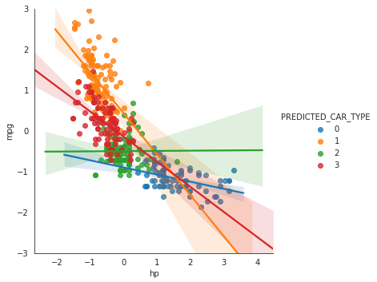

```python
# mpg Vs hp

var = 'hp'

with sns.axes_style("white"):
    plot = sns.lmplot(var,'mpg',data=car_mpg_df_z,hue='PREDICTED_CAR_TYPE')
plot.set(ylim = (-3,3))
```

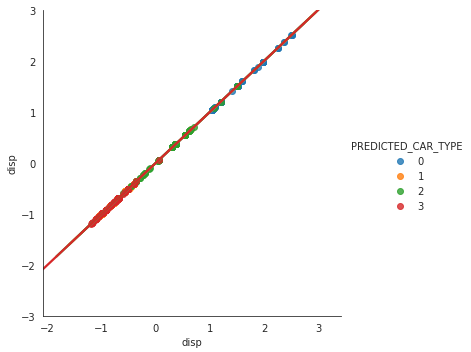

```python
# mpg Vs disp

var = 'disp'

with sns.axes_style("white"):
    plot = sns.lmplot(var,'disp',data=car_mpg_df_z,hue='PREDICTED_CAR_TYPE')
plot.set(ylim = (-3,3))
```

## Hierarchical Clustering

```python
# cophenet index is a measure of the correlation between the distance of points in feature space and distance on dendrogram
# closer it is to 1, the better is the clustering
link_z = linkage(car_mpg_df_z,'ward')
c, coph_dists = cophenet(link_z , pdist(car_mpg_df_z))
```

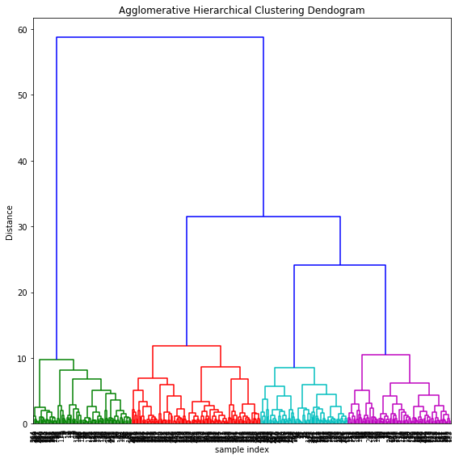

```python
plt.figure(figsize=(8, 8))
plt.title('Agglomerative Hierarchical Clustering Dendogram')
plt.xlabel('sample index')
plt.ylabel('Distance')
dendrogram(link_z, leaf_rotation=90.,color_threshold = 20, leaf_font_size=8. )
plt.tight_layout()
```

#### We can see the 4 types of cluster

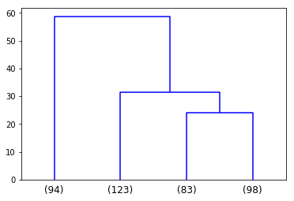

```python
dendrogram(
    link_z,
    color_threshold=10,
    truncate_mode='lastp',  # show only the last p merged clusters
    p=4,  # show only the last p merged clusters
)
plt.show()
```

### Big cluster can further be split if required based on further analysis or business requirements

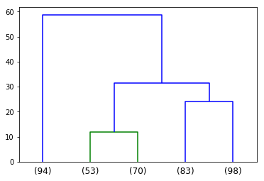

```python
dendrogram(
    link_z,
    color_threshold=15,
    truncate_mode='lastp',  # show only the last p merged clusters
    p=5,  # show only the last p merged clusters
)
plt.show()
```

## Building Linear regression Model for each cluster

```python
car_mpg_df_z.sample(5)
```

|  | cyl | disp | hp | wt | acc | yr | mpg | PREDICTED_CAR_TYPE |
| --- | --- | --- | --- | --- | --- | --- | --- | --- |
| 58 | -0.856321 | -0.921135 | -0.636655 | -0.998401 | 0.519896 | -1.085858 | 0.190289 | 3 |
| 128 | 0.320935 | 0.543257 | -0.112746 | 0.432236 | 0.519896 | -0.544290 | -1.090751 | 2 |
| 192 | 0.320935 | 0.543257 | 0.018232 | 0.452336 | -0.387801 | -0.002721 | -0.194023 | 2 |
| 219 | -0.856321 | -0.685872 | -0.217527 | -0.792673 | -0.024722 | 0.268063 | 0.254341 | 3 |
| 215 | 1.498191 | 1.196232 | 1.197027 | 0.927638 | -0.569341 | -0.002721 | -1.346959 | 0 |

```python
car_mpg_df_z_counts = car_mpg_df_z['PREDICTED_CAR_TYPE'].value_counts()
car_mpg_df_z_counts
```

```
1    114
3     99
0     94
2     91
Name: PREDICTED_CAR_TYPE, dtype: int64
```

```python
cluster_list = car_mpg_df_z_counts.index
cluster_list
```

```
Int64Index([1, 3, 0, 2], dtype='int64')
```

```python
import statsmodels.api as sm
def generateLinearRegressionOLS():
    for cluster_id in cluster_list :
        print("\n\n\nFor cluster Id: ",cluster_id)
        cluster_id_df = car_mpg_df_z[car_mpg_df_z['PREDICTED_CAR_TYPE'] == cluster_id]
        X = cluster_id_df.drop(['mpg','PREDICTED_CAR_TYPE'],axis=1)
        y = cluster_id_df['mpg']
        X_train, X_test, y_train, y_test = train_test_split(X, y, test_size=0.25, random_state=8)
        #regression_model = LinearRegression()
        #regression_model.fit(X_train, y_train)
        #print("Respective coefs")
        #print(pd.DataFrame(regression_model.coef_,X_train.columns))
        #print("\nModel Intercepts: ", regression_model.intercept_)
        #print("\nModel Score: ", regression_model.score(X_test, y_test))
        model = sm.OLS(y_train, X_train).fit()
        predictions = model.predict(X_test)
        print(model.summary())
generateLinearRegressionOLS()
```

```
For cluster Id:  1
                            OLS Regression Results
==============================================================================
Dep. Variable:                    mpg   R-squared:                       0.891
Model:                            OLS   Adj. R-squared:                  0.882
Method:                 Least Squares   F-statistic:                     107.3
Date:                Fri, 04 Oct 2019   Prob (F-statistic):           7.17e-36
Time:                        21:30:40   Log-Likelihood:                -45.027
No. Observations:                  85   AIC:                             102.1
Df Residuals:                      79   BIC:                             116.7
Df Model:                           6
Covariance Type:            nonrobust
==============================================================================
                 coef    std err          t      P>|t|      [0.025      0.975]
------------------------------------------------------------------------------
cyl            0.5793      0.249      2.330      0.022       0.084       1.074
disp          -0.0918      0.375     -0.245      0.807      -0.838       0.654
hp            -0.8302      0.265     -3.129      0.002      -1.358      -0.302
wt            -0.6055      0.235     -2.574      0.012      -1.074      -0.137
acc            0.0051      0.082      0.061      0.951      -0.159       0.169
yr             0.3950      0.097      4.063      0.000       0.202       0.589
==============================================================================
Omnibus:                       13.260   Durbin-Watson:                   1.843
Prob(Omnibus):                  0.001   Jarque-Bera (JB):               14.771
Skew:                           0.836   Prob(JB):                     0.000620
Kurtosis:                       4.172   Cond. No.                         19.1
==============================================================================

Warnings:
[1] Standard Errors assume that the covariance matrix of the errors is correctly specified.



For cluster Id:  3
                            OLS Regression Results
==============================================================================
Dep. Variable:                    mpg   R-squared:                       0.720
Model:                            OLS   Adj. R-squared:                  0.696
Method:                 Least Squares   F-statistic:                     29.18
Date:                Fri, 04 Oct 2019   Prob (F-statistic):           5.16e-17
```

[output cut: 74 more lines]

```
cyl           -0.3877      0.128     -3.039      0.003      -0.643      -0.133
disp           0.2124      0.170      1.246      0.217      -0.128       0.553
hp             0.3768      0.187      2.013      0.048       0.003       0.751
wt            -0.8226      0.172     -4.773      0.000      -1.167      -0.478
acc            0.0838      0.104      0.810      0.421      -0.123       0.291
yr             0.2384      0.062      3.853      0.000       0.115       0.362
==============================================================================
Omnibus:                        1.432   Durbin-Watson:                   1.772
Prob(Omnibus):                  0.489   Jarque-Bera (JB):                0.910
Skew:                           0.267   Prob(JB):                        0.635
Kurtosis:                       3.190   Cond. No.                         6.33
==============================================================================

Warnings:
[1] Standard Errors assume that the covariance matrix of the errors is correctly specified.
```

```python
import statsmodels.api as sm
def generateLinearRegression():
    for cluster_id in cluster_list :
        print("\n\n\nFor cluster Id: ",cluster_id)
        cluster_id_df = car_mpg_df_z[car_mpg_df_z['PREDICTED_CAR_TYPE'] == cluster_id]
        X = cluster_id_df.drop(['mpg','PREDICTED_CAR_TYPE'],axis=1)
        y = cluster_id_df['mpg']
        X_train, X_test, y_train, y_test = train_test_split(X, y, test_size=0.25, random_state=8)
        regression_model = LinearRegression()
        regression_model.fit(X_train, y_train)
        print("Respective coefs")
        print(pd.DataFrame(regression_model.coef_,X_train.columns))
        print("\nModel Intercepts: ", regression_model.intercept_)
        print("\nModel Score: ", regression_model.score(X_test, y_test))
generateLinearRegression()
```

```
For cluster Id:  1
Respective coefs
             0
cyl   0.888057
disp -0.095803
hp   -0.610004
wt   -0.683331
acc   0.030173
yr    0.299061

Model Intercepts:  0.4640732958000817

Model Score:  0.39242962195458403



For cluster Id:  3
Respective coefs
             0
cyl   1.941726
disp -0.838450
hp   -0.245049
wt   -0.484236
acc  -0.114408
yr    0.056924

Model Intercepts:  0.7959787023909606

Model Score:  -0.3714115083850522



For cluster Id:  0
Respective coefs
             0
cyl   0.110954
disp -0.101006
hp   -0.101764
wt   -0.091856
acc  -0.218587
yr    0.173585

Model Intercepts:  -1.0062562975908251

Model Score:  0.6513308932967024



For cluster Id:  2
Respective coefs
             0
cyl   0.131466
disp -0.064554
hp   -0.189620
wt   -0.322572
acc  -0.084792
yr    0.206748

Model Intercepts:  -0.4047919877529087

Model Score:  0.574148338188994
```

## Building model without clusters

```python
import statsmodels.api as sm
# Fit and make the predictions by the model
X = car_mpg_df_z.drop(['mpg','PREDICTED_CAR_TYPE'],axis=1)
y = car_mpg_df_z['mpg']
X_train, X_test, y_train, y_test = train_test_split(X, y, test_size=0.25, random_state=8)
model2 = sm.OLS(y_train, X_train).fit()
predictions = model2.predict(X_test)
print(X.shape)
# Print out the statistics
model2.summary()
```

```
(398, 6)
```

OLS Regression Results

| Dep. Variable: | mpg | R-squared: | 0.811 |
| --- | --- | --- | --- |
| Model: | OLS | Adj. R-squared: | 0.807 |
| Method: | Least Squares | F-statistic: | 208.2 |
| Date: | Fri, 04 Oct 2019 | Prob (F-statistic): | 2.41e-102 |
| Time: | 21:35:36 | Log-Likelihood: | -179.03 |
| No. Observations: | 298 | AIC: | 370.1 |
| Df Residuals: | 292 | BIC: | 392.2 |
| Df Model: | 6 |  |  |
| Covariance Type: | nonrobust |  |  |

|  | coef | std err | t | P>\|t\| | [0.025 | 0.975] |
| --- | --- | --- | --- | --- | --- | --- |
| cyl | -0.0685 | 0.083 | -0.824 | 0.411 | -0.232 | 0.095 |
| disp | 0.1434 | 0.114 | 1.262 | 0.208 | -0.080 | 0.367 |
| hp | -0.0415 | 0.075 | -0.549 | 0.583 | -0.190 | 0.107 |
| wt | -0.7653 | 0.083 | -9.254 | 0.000 | -0.928 | -0.603 |
| acc | 0.0179 | 0.042 | 0.429 | 0.668 | -0.064 | 0.100 |
| yr | 0.3587 | 0.029 | 12.399 | 0.000 | 0.302 | 0.416 |

| Omnibus: | 28.579 | Durbin-Watson: | 1.948 |
| --- | --- | --- | --- |
| Prob(Omnibus): | 0.000 | Jarque-Bera (JB): | 42.051 |
| Skew: | 0.631 | Prob(JB): | 7.39e-10 |
| Kurtosis: | 4.339 | Cond. No. | 10.6 |

Warnings:  
[1] Standard Errors assume that the covariance matrix of the errors is correctly specified.

```python
import statsmodels.api as sm
# Fit and make the predictions by the model
X = car_mpg_df_z.drop(['mpg','PREDICTED_CAR_TYPE'],axis=1)
y = car_mpg_df_z['mpg']
X_train, X_test, y_train, y_test = train_test_split(X, y, test_size=0.25, random_state=8)
regression_model_full = LinearRegression()
regression_model_full.fit(X_train, y_train)
print("Respective coefs")
print(pd.DataFrame(regression_model_full.coef_,X_train.columns))
print("\nModel Intercepts: ", regression_model_full.intercept_)
print("\nModel Score: ", regression_model_full.score(X_test, y_test))
```

```
Respective coefs
             0
cyl  -0.068433
disp  0.144237
hp   -0.041641
wt   -0.765967
acc   0.018121
yr    0.358556

Model Intercepts:  0.00653548326896516

Model Score:  0.7995253658559445
```

#### Cluster model scores can be improved by using cross validation